# Project 2: Data Mining, Classification, Prediction

SDS322E

# Mining, Classification, Prediction

Mark Kazmierczak, mjk2299

### Introduction

The the Affairs data that was used for this project was taken from https://vincentarelbundock.github.io/Rdatasets/datasets.html. This data collected by survey in 1969 consists of 7 numeric variables that include age, years married, a rating of satisfaction of the marriage, education level, occupation, and the number of affairs over the past year. Two categorical variables include gender and whether or not there were children in the marriage. The categorical variable of “faithful” was added the describe whether a person had or had not engaged in an affair over the year prior. I choose this data because the data from my previous project was not compatible for this project so I searched for a dataset that would maximize the learning objectives for the second half of the semester. This data has an nice mix of numeric and categorical variables with 601 observations which I believe will be suitable for practicing the skills in this project.

```r
library(tidyverse)
set.seed(22)
# read your datasets in here, e.g., with read_csv()
affairs <- read_csv("~/project2/Affairs (1).csv")

# Addition of categorical variable 'faithful'
infidelity <- affairs %>% select(-1) %>% mutate(faithful = ifelse(affairs >
    0, 0, 1))
```

### Cluster Analysis

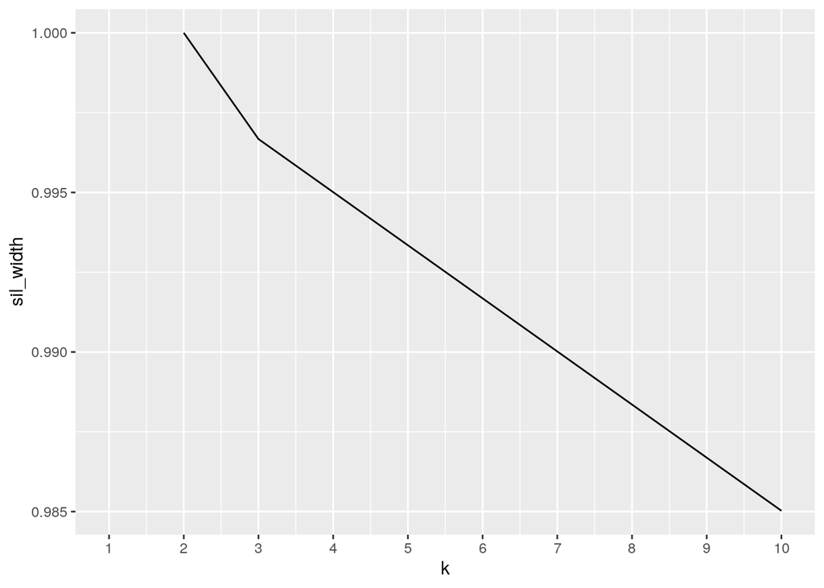

```r
library(cluster)
library(GGally)

infidelity.cluster <- infidelity %>% select(1, 3, 4, 6, 9)
# Determine k
sil_width <- vector()
for (i in 2:10) {
    pam_fit <- pam(infidelity, diss = TRUE, k = i)
    sil_width[i] <- pam_fit$silinfo$avg.width
}

ggplot() + geom_line(aes(x = 1:10, y = sil_width)) + scale_x_continuous(name = "k",
    breaks = 1:10)
```

```r
# PAM
infidelity_pam <- pam(infidelity.cluster, k = 2)

infidelity_pam
```

```
## Medoids:
##       ID affairs age yearsmarried religiousness rating
## [1,] 580       1  42           15             3      3
## [2,]  30       0  27            4             3      4
## Clustering vector:
##   [1] 1 2 1 1 2 2 2 1 1 2 1 2 1 2 2 1 1 2 2 2 2 2 2 2 2 2 2 1 2 2 1 2 2 1 2 2 1
##  [38] 2 2 2 2 1 2 2 2 2 2 1 2 1 2 2 2 2 2 1 2 1 2 2 1 1 2 2 2 1 1 1 2 2 2 2 2 1
##  [75] 1 2 2 2 2 1 2 1 2 1 2 2 1 2 2 1 1 1 1 1 2 1 1 1 1 1
##  [ reached getOption("max.print") -- omitted 501 entries ]
## Objective function:
##    build     swap
## 7.702443 6.450091
##
## Available components:
##  [1] "medoids"    "id.med"     "clustering" "objective"  "isolation"
##  [6] "clusinfo"   "silinfo"    "diss"       "call"       "data"
```

```r
# average sil width
infidelity_pam$silinfo$avg.width
```

```
## [1] 0.5176765
```

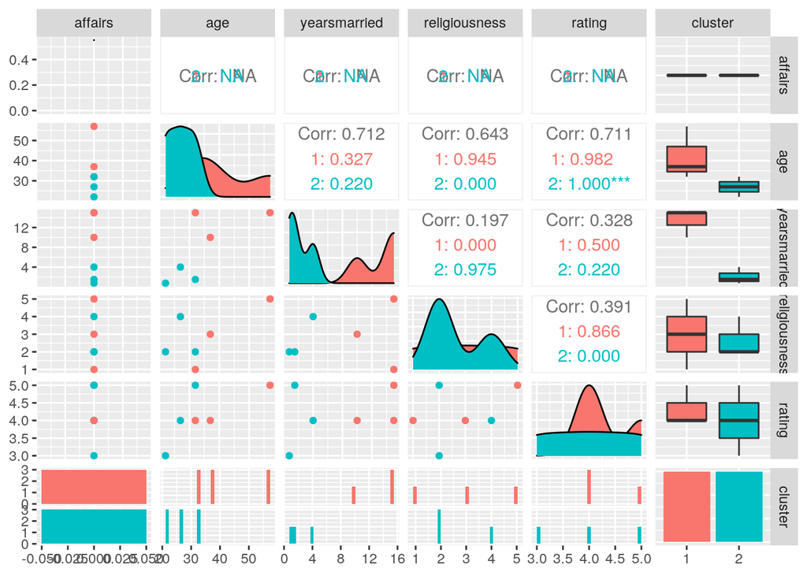

```r
# Pairwise Combinations
infidelity.cluster %>% mutate(cluster = as.factor(infidelity_pam$clustering)) %>%
    head() %>% ggpairs(aes(color = cluster))
```

### Dimensionality Reduction with PCA

```r
# PCA

infidelity.pcadata <- infidelity %>% select(-10) %>% select_if(is.numeric)

infidelity.pca <- princomp(infidelity.pcadata, cor = T)

summary(infidelity.pca, loadings = T)
```

```
## Importance of components:
##                           Comp.1    Comp.2    Comp.3    Comp.4     Comp.5
## Standard deviation     1.4339476 1.2444559 1.1301189 0.8713945 0.83305652
## Proportion of Variance 0.2937437 0.2212387 0.1824527 0.1084755 0.09914045
## Cumulative Proportion  0.2937437 0.5149823 0.6974350 0.8059105 0.90505092
##                            Comp.6     Comp.7
## Standard deviation     0.67734638 0.45370189
## Proportion of Variance 0.06554259 0.02940649
## Cumulative Proportion  0.97059351 1.00000000
##
## Loadings:
##               Comp.1 Comp.2 Comp.3 Comp.4 Comp.5 Comp.6 Comp.7
## affairs        0.225  0.115  0.626  0.157  0.715
## age            0.616        -0.169 -0.318                0.693
## yearsmarried   0.615  0.155 -0.127 -0.283               -0.706
## religiousness  0.188  0.127 -0.603  0.707  0.288
## education      0.168 -0.673                       0.716
## occupation     0.207 -0.641  0.112  0.225        -0.681 -0.103
## rating        -0.292 -0.286 -0.431 -0.489  0.625 -0.133
```

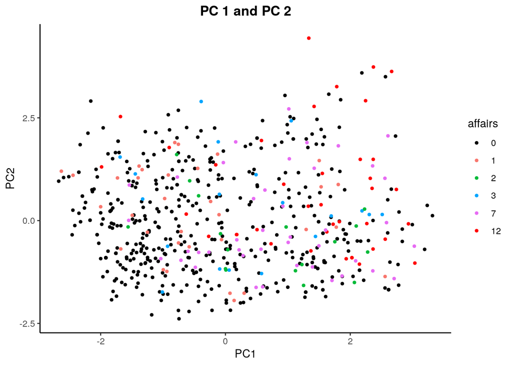

```r
# visualize

library(ggplot2)

infidelity.pca.df <- infidelity.pca$scores %>% as.data.frame()

infidelity.pca.df <- infidelity.pca.df %>% mutate(affairs = as.factor(infidelity.pcadata$affairs))

infidelity.pca.df %>% ggplot(aes(Comp.1, Comp.2, color = affairs)) +
    geom_point(size = 1) + xlab("PC1") + ylab("PC2") + scale_color_manual(values = c("black",
    "#F8766D", "#00BA38", "#00A5FF", "#E76BF3", "Red")) + theme_classic() +
    theme(plot.title = element_text(hjust = 0.5, face = "bold")) +
    ggtitle("PC 1 and PC 2")
```

For the PCA all of the numeric variables were used. PC1 and PC2 combined accounted for 51.50% of the variation observed in this dataset.PC1 and PC2 where plotted on a scatter plot on the points were colored by the affairs variable. Black dots represent individuals that did not engage in affairs while colored dots represent those that did. A high score in PC1 is for people that scored high in both age and years married but low in the rating variable. A high score in PC2 is for people that scored low in both education, occupation ,and the rating variable. It appears that individuals that did not engage in an affair are slightly more condensed the region of low PC1 and low PC2 scores. Individuals that did have affairs appear to have a high concentration in the high PC1 region. ### Linear Classifier

```r
# linear classifier code here

infidelity.glm <- glm(data = infidelity, faithful ~ age + rating +
    yearsmarried + religiousness + education, family = "binomial")


faithful_prob <- predict(infidelity.glm, type = "response")

# class diag
class_diag(faithful_prob, truth = infidelity$faithful, positive = 1)
```

```
##            acc   sens   spec    ppv   f1   ba    auc
## Metrics 0.7637 0.9667 0.1533 0.7744 0.86 0.56 0.7047
```

```r
# confusion matrix

table(Actual = infidelity$faithful, Predicted = faithful_prob >
    0.5)
```

```
##       Predicted
## Actual FALSE TRUE
##      0    23  127
##      1    15  436
```

```r
# cross-validation of linear classifier here
set.seed(22)
k = 10
data <- sample_frac(infidelity)
folds <- rep(1:k, length.out = nrow(data))
diags <- NULL

i = 1
for (i in 1:k) {
    # create training and test sets
    train <- data[folds != i, ]
    test <- data[folds == i, ]
    truth <- test$faithful


    fit <- infidelity.glm

    probs <- predict(fit, newdata = test, type = "response")

    diags <- rbind(diags, class_diag(probs, truth, positive = 1))
}


summarize_all(diags, mean)
```

```
##       acc    sens    spec     ppv      f1      ba     auc
## 1 0.76367 0.96625 0.15207 0.77403 0.85845 0.55915 0.69408
```